# Tracking the Economic Effects of Tariffs

The Budget Lab at Yale

April 02, 2026

## Introduction

In response to new tariff announcements, The Budget Lab (TBL) regularly estimates fiscal and macroeconomic effects resulting from policy; TBL published its latest report on [March 9th](https://budgetlab.yale.edu/research/state-tariffs-march-9-2026), and we aim to update these projections as we refine our methodology and as policies change. These analyses rely on projections from well-respected economic and trade models, including the MA/US macroeconometric model (currently maintained by S&P Global) for short-run analysis and the Global Trade Analysis Project (GTAP) model for medium/long-run analysis.

This analysis provides monthly updates on how actual economic indicators are responding to tariff changes, which serves as both a check on the assumptions made by economic models and as well as a real-time assessment of how tariffs are impacting the US economy. In particular, we consider the impact of tariffs on revenues, prices, trade, and labor markets. Critically, these are not causal estimates of the effect of tariffs on the economy, but rather constitute a descriptive attempt to explore how the economy is changing with tariffs. There are a number of other economic changes happening concurrently, including but not limited to the growth of generative AI and the passage of the One Big Beautiful Bill Act, which we do not control for in the series presented below. This report was updated using data as of Thursday, April 2nd, 2026.

## Tariff Rates and Revenue

Tariffs are a tax on imports, therefore higher tariffs will increase revenues if their effect on imports is not sufficiently prohibitive. TBL’s [Tariff Rate Tracker](https://github.com/Budget-Lab-Yale/tariff-rate-tracker) follows the full schedule of statutory tariff rates as encoded in the Harmonized Tariff Schedule (HTS), weighted by 2024 import values. As of April 02, 2026, the import-weighted average effective tariff rate stood at 11.1% (see Figure A1 in the Appendix below for a decomposition by tariff authority). This rate incorporates the changes to the tariff regime after the Supreme Court held 6–3 in *Learning Resources, Inc. v. Trump* that the use of IEEPA to impose tariffs exceeded presidential authority. This includes both the removal of all IEEPA-based tariffs and the implementation of Section 122 tariffs for a 150 day period. Tariffs imposed using other authorities remain in effect. We anticipate that refunds will be issued for revenue collected via IEEPA-based tariffs. The customs revenue data presented in this report do not yet cover the post-SCOTUS period, and substantial uncertainty remains, both about the timing of refunds and the eventual structure of the post-IEEPA tariff regime.

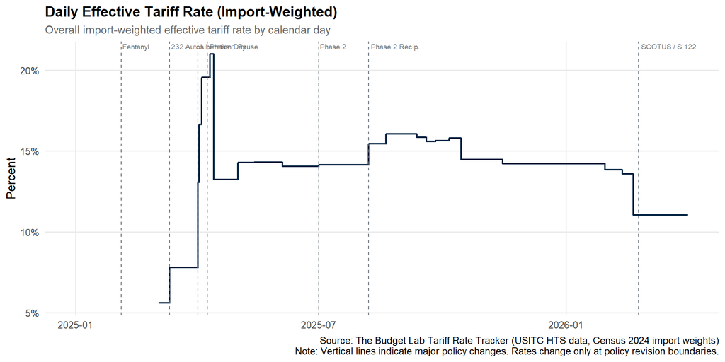

While statutory rates provide a measure of tariff policy, the effective tariff rate—customs duties actually collected as a share of import value—has been notably lower. This gap reflects trade diversion, exemptions, exclusion processes, collection lags, and the fact that not all statutory provisions have fully phased in. Before the 2025 tariff announcements, the average effective US tariff rate was 2.7% (2022–2024 average). The new 2025 tariffs have pushed the average effective US rate to 10.6%.

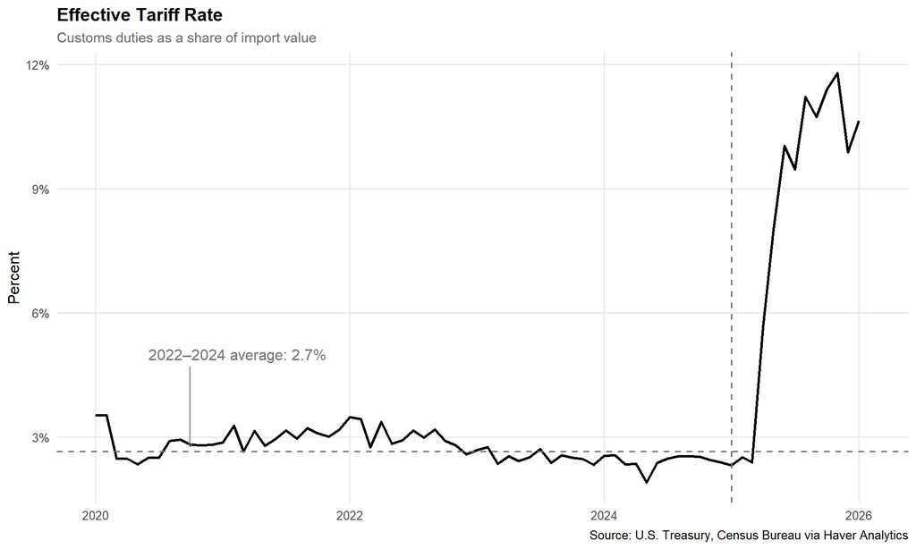

The tariff revenue and rate numbers reported here are a different measure than the numbers reported in TBL’s State of Tariff Report. The effective tariff rates (ETRs) reported here are actual tariff duties divided by the value of customs, meaning that they incorporate any avoidance behavior by firms, importers, or other actors. The effective tariff rates reported in TBL’s State of Tariff Report are model-based estimates of the average rates across sectors, weighted by 2024 trade flows. In that report, we include two measures of average ETRs: pre-substitution and post-substitution. In our modeling of the general revenue effects of tariffs, our last pre-SCOTUS estimate of tariff revenue was projected to raise $246 billion in annual revenue for fiscal year (FY) 2026 (conventionally). This is lower than the annualized revenue we would expect if monthly tariff revenue remained at its current level (2-month average of January and February projected forward) for the rest of the fiscal year ($327 billion). However, the revenue estimates in the State of Tariff Report account for decreases in other revenue sources, like federal payroll and corporate income taxes, following the methodology of the [U.S. Congressional Budget Office](https://www.cbo.gov/publication/58549). Adjusting for that gives us a simulated annual revenue of $319 billion, notably closer to the annualized tariff revenue level suggested by the customs data.

Higher effective tariff rates have translated directly into additional customs revenue. Before 2025, the US collected $7.6 billion a month in net customs duty revenues. Since then, tariffs have raised roughly $214.7 billion in revenues above the 2022–2024 average, with $175.5 billion collected over the course of 2025 and about $19.0 billion of that new tariff revenue posted in February 2026 alone, though again, approximately $165 billion may be returned to importers and consumers via refunds of IEEPA tariffs.

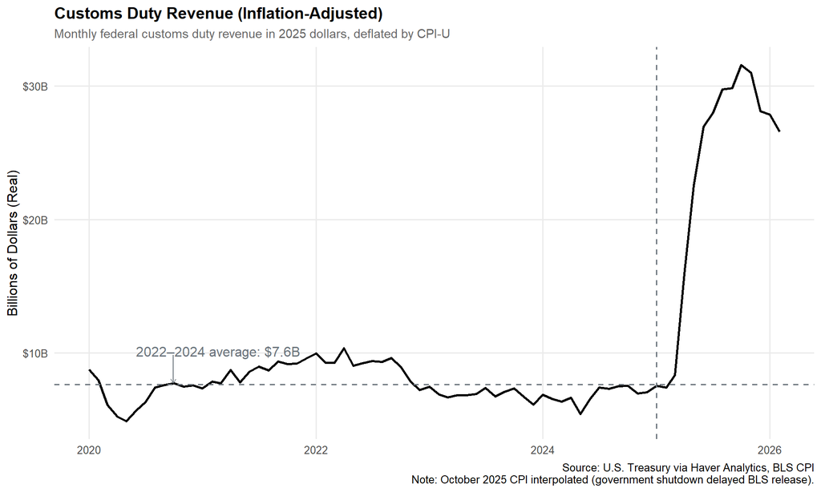

## Prices and Consumer Passthrough

One of the most debated questions around tariffs is to what extent they are leading to higher consumer prices. Tariffs are taxes that add to the cost of imported goods. Different groups can bear this cost, or incidence: foreign producers (in the form of accepting lower prices on their exports), American importers and businesses (in the form of lower profit margins), and American consumers (in the form of lower real after-tax incomes). Moreover, tariffs reduce productivity and thereby real U.S. income (even when including tariff revenue) by reducing the efficiency of resource allocation across countries and increasing the marginal cost of investment. After-tax real incomes in turn can fall either from a rise in realized prices, holding nominal income constant, or a fall in nominal income.

### Overall Goods Prices

One possible indication that tariffs are raising consumer goods prices is that goods prices have increased since the beginning of the year, both in absolute terms and against reasonable estimates of pre-2025 trend. We estimate the pre-2025 trend using a local projection method with recession and pandemic controls. See the [accompanying Methodology page](https://budgetlab.yale.edu/research/methodological-appendix-tracking-economic-effects-tariffs) for full details. We find similar differences when the trend is calculated using a simple log-linear approach. During 2025 through January, PCE core goods prices (goods excluding volatile food & energy components) rose 2.3%, versus -0.1% over the same 13-month period starting in 2023. The difference is even starker with PCE durable goods prices, which rose 2.5%, versus -2.0% over the same period starting in 2023. Core goods and durable goods were 3.4% and 4.1% above TBL’s estimate of pre-2025 trend in January.

Versions of Figures 4 and 5 using the log-linear trend approach are included in the Appendix below.

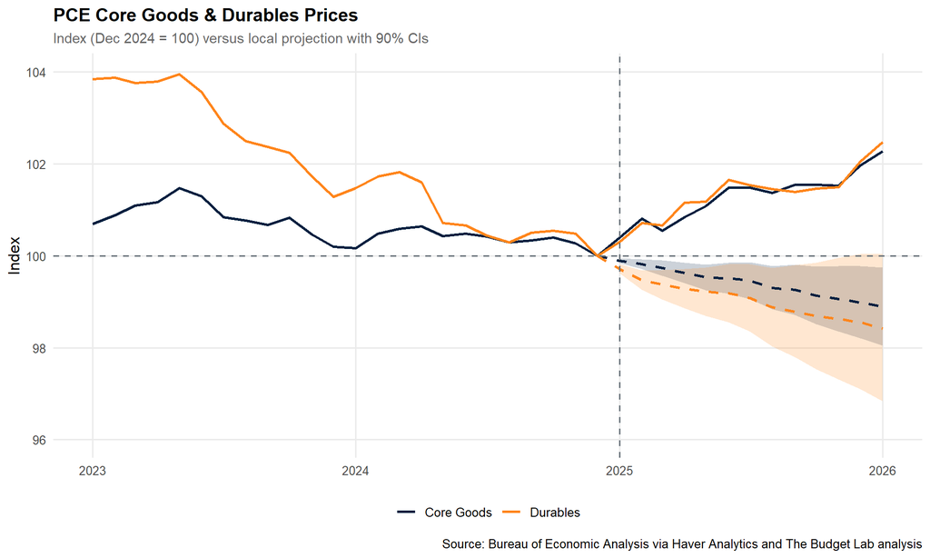

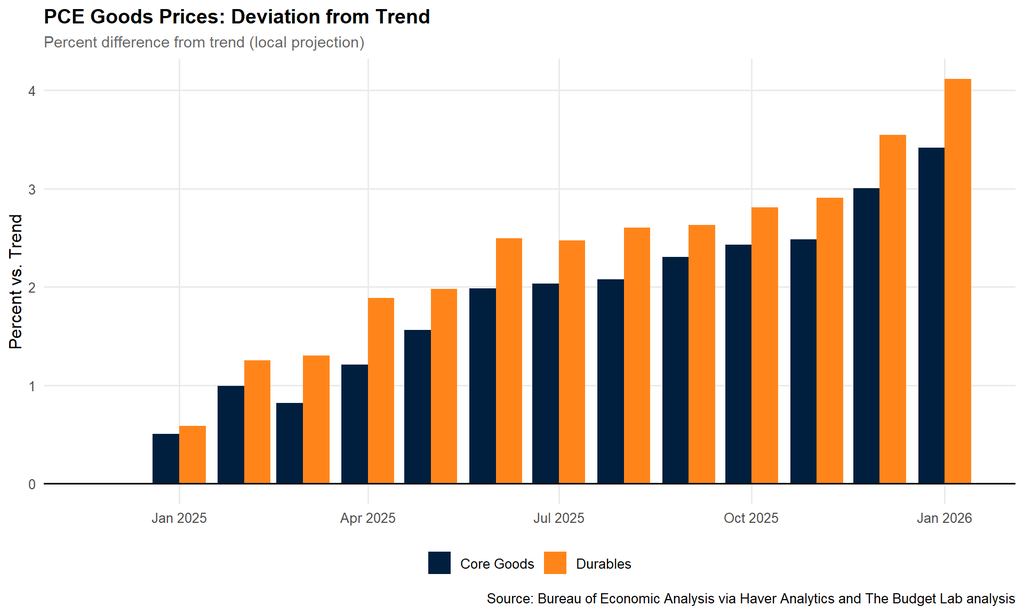

### Imported PCE Goods Prices

When we construct a price index that reweights standard PCE component price indices by their import content—weighting categories like electronics, motor vehicles, and apparel more heavily, and domestic-heavy categories less—the deviation remains, though it is less extreme for core goods. This **Imported PCE Goods Price Index** measures price changes in the goods most exposed to imports and therefore tariffs. As of January, the imported core goods index is 2.9% above trend and the imported durables index is 3.4% above trend, compared to 3.4% and 4.1% for the standard PCE indices. See the [accompanying Methodology page](https://budgetlab.yale.edu/research/methodological-appendix-tracking-economic-effects-tariffs) for details on index construction.

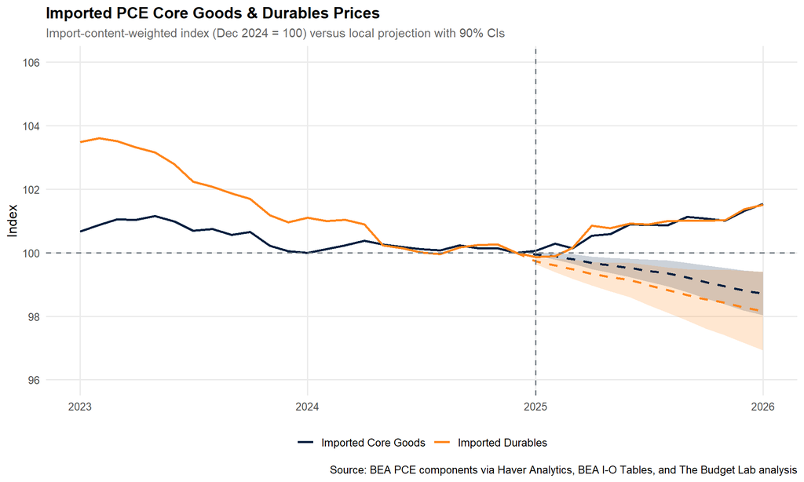

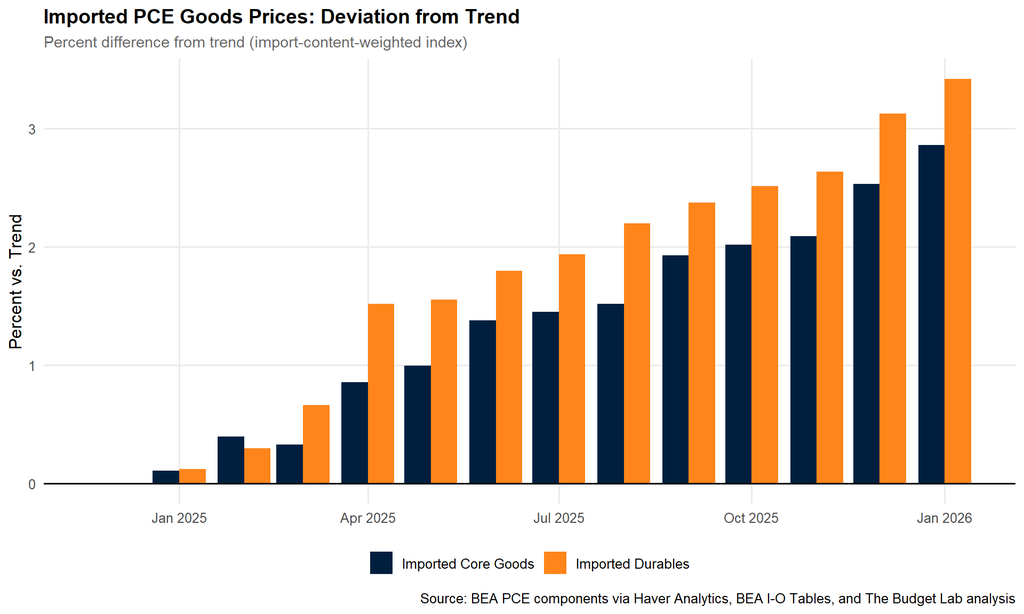

### Implied Consumer Passthrough

In its modeling, TBL assumes that passthrough of tariffs to consumer prices will ultimately reach 100%. Studies of the 2018 tariffs find near-complete passthrough to import prices at the border ([Flaaen, Hortacsu & Tintelnot 2020](https://www.aeaweb.org/articles?id=10.1257/aer.20190611); [USITC 2023](https://www.usitc.gov/publications/332/pub5405.pdf)). However, passthrough from the border to consumer shelves was substantially incomplete in the short run, with importers absorbing tariff costs through compressed margins (USITC 2023, Ch. 6). Our assumption of eventual 100% passthrough reflects the expectation that margin compression is unsustainable—importers will eventually pass costs forward or exit. Both of these studies also focus on much narrower tariff increases than the broader and more aggressive increases over the last year, and the 2025 tariffs come after a period of inflation that may have changed how price-sensitive consumers are. In this context, comparing the rise in overall goods prices against what we would mechanically expect given the rise in tariffs, we can estimate an implied “spot” passthrough—measuring where we are on the journey from border to consumer prices—as of January 2026.

In January 2026 (the month of the latest detailed Census trade data), the actual average effective tariff rate was 10.6%. But as mentioned earlier, there are several reasons why it takes time for tariff policy to fully flow through into realized revenues. But this rate, calculated based on all revenues and imports, includes products and content that will not ultimately be purchased by consumers, such as business investment and exports. TBL therefore calculated average tariff rates on imported consumer goods. For imported core PCE goods, the average import-weighted effective tariff rate was 13.1% in the most recent month, up from a 2022–2024 average of roughly 2.7% (the 2025 annual average was 8.7%). For just imported PCE durables, the most-recent-month rate was 13.3%, up from roughly 2.7% (2025 annual average: 9.0%). Given these shifts and the import share of PCE (total import content—including indirect imports through the supply chain—is 32.1% of core goods spending; see [accompanying Methodology page](https://budgetlab.yale.edu/research/methodological-appendix-tracking-economic-effects-tariffs)), we would expect full passthrough price effects from the actual tariff increases in 2025 so far to add 3.3 and 3.0 percentage points through January 2026 for core goods and durables prices, respectively.

We estimate the rise in imported core goods and durable prices in three ways. The first, and our preferred approach, uses the trend estimates reported in Figure 6 as the counterfactual level of prices but-for tariffs. The second approach uses data from 2023-2024 to project forward pre-2025 prices. The third approach moves away from relying on estimating trends, and rather assumes that prices would have remained at their December 2024 level. It therefore uses the change in prices during 2025 through January. We think that this approach underestimates true price increases from the tariffs by ignoring counterfactuals, but provides an easy lower-bound estimate.

The results of each are shown below, with one table for June 2025 and one for the most recent month of data, January 2026. Tables 1a and 1b use these category-specific tariff rates rather than the economy-wide effective rate, since the tariff burden varies across consumer goods categories. Passthrough tables using overall PCE prices (as opposed to the imported goods) are available in the Appendix below.

Table 1a. Implied Passthrough – Imported PCE Core and Durable Goods Prices (June 2025). Passthrough calculation components, estimated price change, and estimated passthrough rates.

| Category | Inputs Import Share | Inputs Tariff Increase | Inputs Expected Effect | Price Changes 2025 Change | Price Changes vs LP Trend | Price Changes vs Log-Linear | Implied Passthrough 2025 Change | Implied Passthrough vs LP Trend | Implied Passthrough vs Log-Linear |
| --- | --- | --- | --- | --- | --- | --- | --- | --- | --- |
| Imported Core Goods | 32.1% | 8.4 pp | 2.7% | 0.9% | 1.4% | 1.2% | 33% | 51% | 43% |
| Imported Durables | 28.0% | 8.9 pp | 2.5% | 0.9% | 1.8% | 2.0% | 37% | 72% | 79% |

Table 1b. Implied Passthrough – Imported PCE Core and Durable Goods Prices (January 2026). Passthrough calculation components, estimated price change, and estimated passthrough rates.

| Category | Inputs Import Share | Inputs Tariff Increase | Inputs Expected Effect | Price Changes 2025 Change | Price Changes vs LP Trend | Price Changes vs Log-Linear | Implied Passthrough 2025 Change | Implied Passthrough vs LP Trend | Implied Passthrough vs Log-Linear |
| --- | --- | --- | --- | --- | --- | --- | --- | --- | --- |
| Imported Core Goods | 32.1% | 10.4 pp | 3.3% | 1.5% | 2.9% | 2.1% | 46% | 86% | 64% |
| Imported Durables | 28.0% | 10.6 pp | 3.0% | 1.5% | 3.4% | 3.8% | 51% | 115% | 128% |

**Notes:**

- **LP (Local Projection)**: Price deviation from trend estimated using local projections with recession/pandemic controls (1996–2024 estimation period). See [accompanying Methodology page](https://budgetlab.yale.edu/research/methodological-appendix-tracking-economic-effects-tariffs).
- **Log-Linear**: Price deviation from simple log-linear trend fit to 2023–2024 data.
- **Simple**: Raw price change during 2025 through January with no trend adjustment.
- Tariff rates are category-specific effective rates from USITC trade data: core goods 13.1%, durables 13.3% (vs 2.7% baseline). Economy-wide effective rate as of January 2026: 10.6%.

### Import Prices

As noted above, there are other groups beyond US consumers that might bear the burden of tariffs. For some of these groups (e.g. firms and their shareholders) it is difficult to observe these effects directly. However, we can observe import prices: if foreign producers are willing to accept lower prices on their exports, the incidence of tariffs could fall, at least in part, on them. Below, we plot non-petroleum import prices, and find that in recent months prices have risen over their pre-2025 trend. This is a noisy series, so this effect should not be viewed as causal, but the evidence indicates that foreign producers are not willing to accept lower prices on imports, rather the opposite.

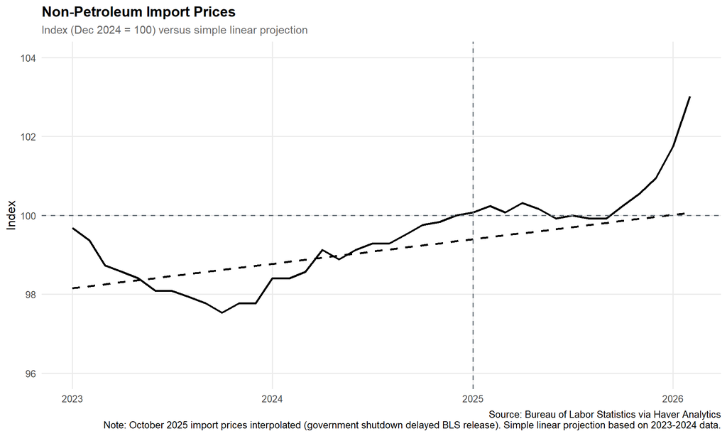

*Note: October 2025 non-petroleum import price data were not published by BLS due to the [government shutdown](https://www.bls.gov/mxp/notices/2026/availability-of-oct-2025-mxpi-in-bls-database.htm). The October value is interpolated as the average of September and November 2025.*

## The Labor Market

Tariffs have the capacity to impact the labor market via different channels that operate over different time frames. Over the short run, prior to substantial effects on consumer or firm behavior, employment might not respond substantially to tariffs. However, over the medium-to-long term, the net effect of tariffs on employment depends on their overall effect on demand, the responses of the Federal Reserve to keep the economy at full-employment, and any positive (e.g. manufacturing) or negative (e.g. construction) sectoral effects that could emerge.

So far, there is no definitive indication of any effect of tariffs on the aggregate job market. Total non-farm employment as of February 2026 changed by +0.2M jobs relative to the level of employment one year earlier. This is lower than that same statistic from one year prior (+1.1M).

However, the overall labor market might not be as affected as certain industries that are more exposed to tariffs. We therefore construct indices of tariff-sensitive employment, which measure employment weighted by industry-level tariff exposure.

For industry $j$, commodity $c$, and month $t$:

$$I_t = \sum_j E_{j,t} \times w_j, \quad
w_j = \sum_c \tau_c \times R_{c,j} \times s_c$$

Where $E_{j,t}$ is employment, $\tau_c$ is the tariff rate, $R_{c,j}$ is the total requirement of commodity $c$ per dollar of industry $j$’s output (from the BEA Leontief inverse), and $s_c$ is the direct import share. This Leontief-adjusted weighting captures tariff cost pressure at every tier of the supply chain. The index is calculated using the most recent month’s tariff rates. We calculate two versions of this index, one for all non-farm covered employment, and one for manufacturing.

Looking at the overall index, there is some evidence of weakening employment during 2025: the index changed by -0.6% during 2025 through February, which is 0.9% less than the pre-2025 trend would have predicted, and 0.5% below the December-to-February change observed in 2024. When we just look at tariff-sensitive manufacturing employment, the manufacturing index changed by -0.9%, versus -0.7% predicted by a simple linear trend. In other words, there are some indications of weakness in tariff-exposed employment overall, but not in the manufacturing sector. It is worth noting, however, that both of these comparisons are illustrative only, and more rigorous work is necessary to determine the short-term effects of tariffs on employment.

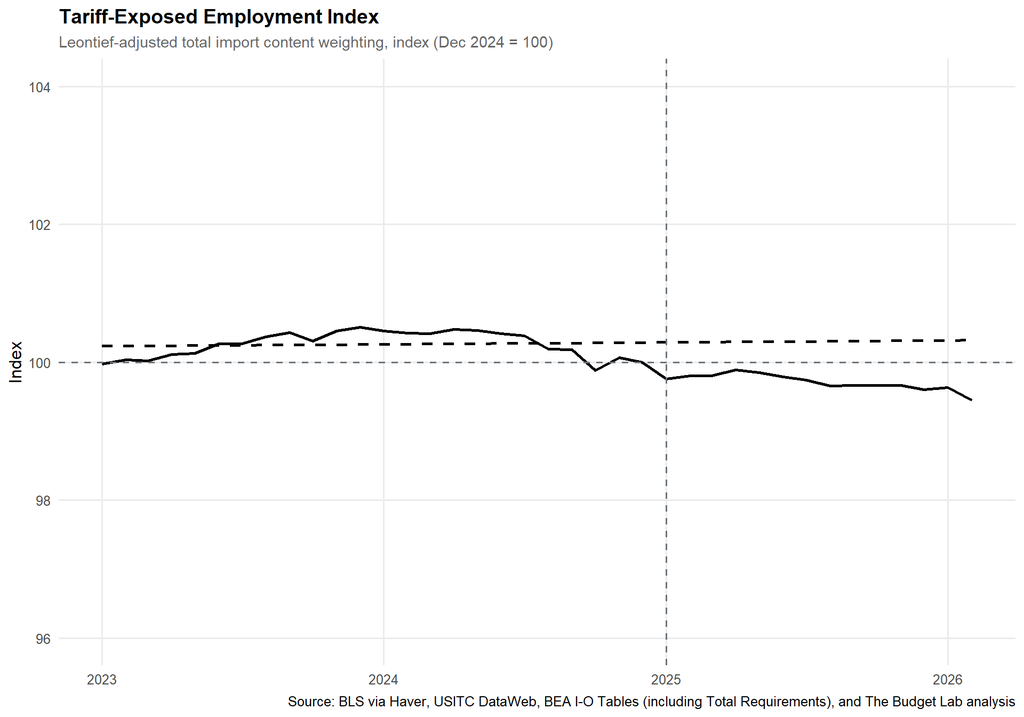

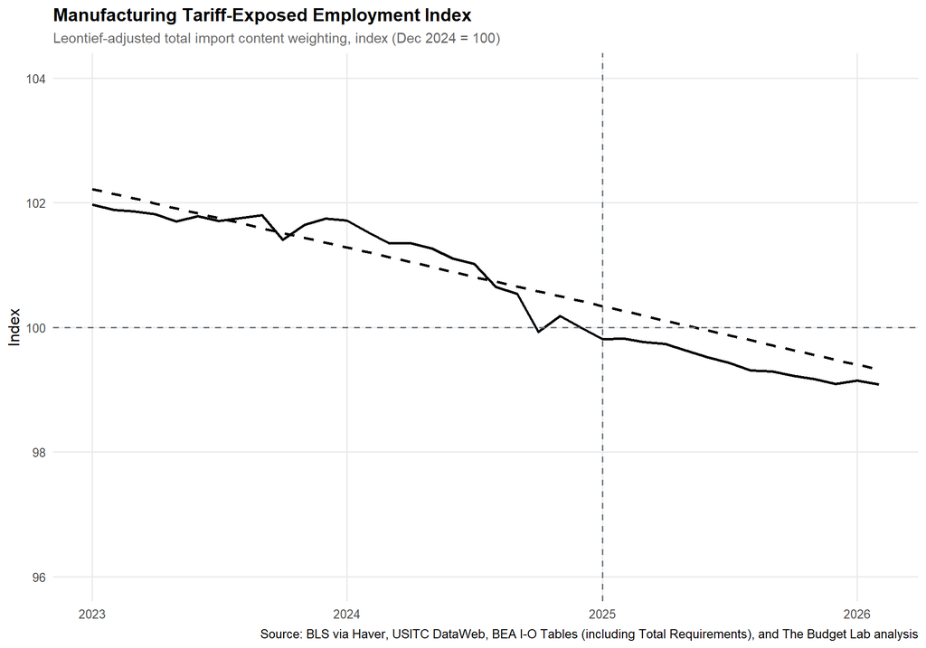

## Industrial Output

Building on the analysis of tariff-sensitive manufacturing employment above, we also consider the evolution of industrial production in this same sector. The manufacturing industrial production index is constructed by the Federal Reserve Board and measures real output of manufacturing industries. We plot the index from 2021 onward, and find that during 2025 through February, the index has changed by +2.2%, though it is worth noting it is possible this is due to mean-reversion rather than to any tariff-related effect. In this case, the 2-year pre-trend plotted below may not be the appropriate counterfactual.

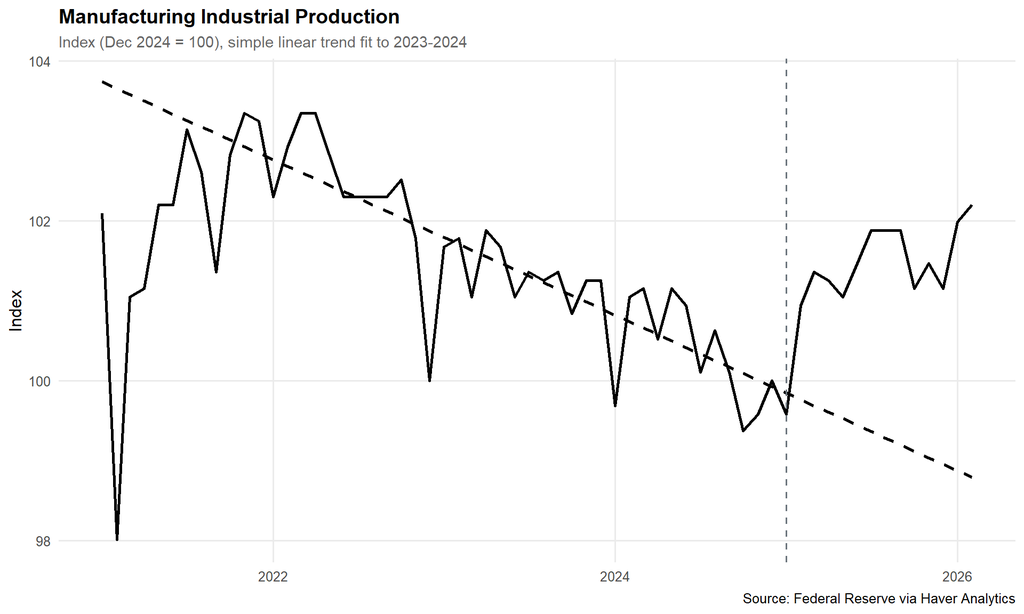

## The Strength of the US Dollar

A conventional assumption in economics is that tariffs, when faced with incomplete retaliation from other countries, will cause either an appreciation in the levying country’s currency and/or a depreciation in the currencies of the other countries. This is because the relative demand for the levying country’s currency rises as their consumers and businesses buy fewer imports. The [Budget Lab’s tariff modeling](https://budgetlab.yale.edu/research/state-tariffs-march-9-2026) has assumed that currency adjustments offset just under one-fifth of the cost of US tariffs to US consumers & businesses without foreign retaliation.

These currency movements will affect the price of imports for consumers. While stronger currencies make imported goods cheaper for residents, weaker currencies have the opposite effect, making imports more expensive. A weakening US dollar exacerbates the price impact of tariffs by making all imports more expensive in dollar terms.

It is unclear what explains these currency movements. As a first order effect, US tariffs may indeed be putting upward pressure on the US dollar but other factors, like a deteriorating economic outlook, shifting views on the credibility of US institutions, the role of the US dollar in the global economy, and expectations of lower interest rates, are likely exerting downward pressure. The real trade-weighted dollar also entered 2025 roughly 20.3% stronger than its long-run average level (2000–2024), so mean reversion may also be a factor in dollar movement.

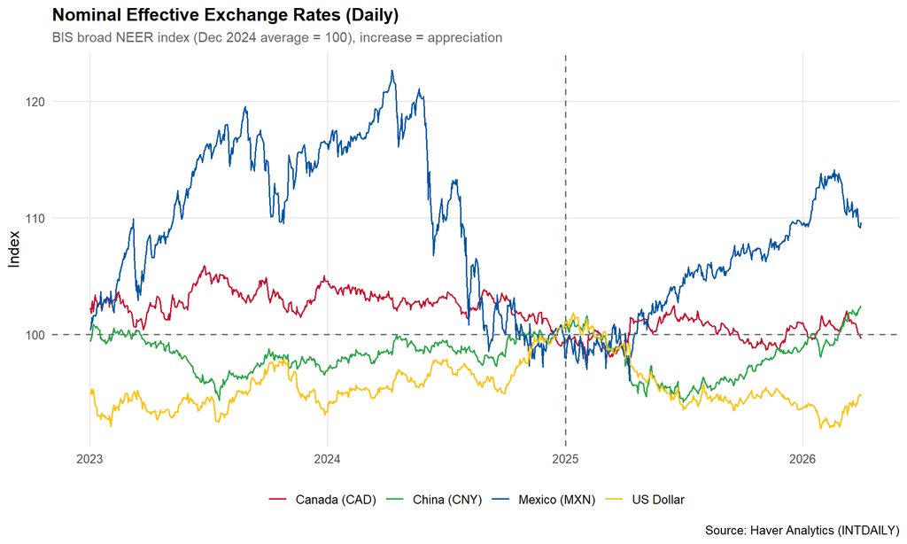

## Imports & Exports

A country’s trade deficit, or the amount by which their imports from other countries exceed their exports to those countries, can be impacted by tariffs if the higher prices of non-domestic goods induces a shift in purchasing by consumers and businesses. However, if the currency of the levying country appreciates as a result of tariffs, this will drive down the relative price of imports, meaning that any sort of persistent reduction in the trade deficit due to tariffs is unlikely in the long run. We are still in the early days of any such transition, and, as noted above, the changes in the value of the dollar might be driven by other factors, meaning that the expected offsetting effects of a (relatively) stronger dollar might not materialize. It is therefore difficult to evaluate the medium-to-long-term effects of tariffs on the trade deficit.

There are, however, some notable dynamics in the short-term reaction of imports over the last year. First, between December 2024 and March 2025, real imports moved from 4.2% to 22.0% above the pre-2025 trend—a 17.8 percentage point increase in the gap, equal to $50.4 billion in real 2025 dollars—as consumers and businesses sought to make purchases ahead of tariffs taking effect. Starting in April, imports declined, and as of January 2026 imports have been on average -6.3% below the pre-2025 trend. Real exports rose more modestly (in absolute terms) than imports, and are 4.6% above trend as of January 2026.

Cumulatively, as of January 2026, imports are down $16.4 billion (real 2025 USD) from December 2024 relative to trend. This rough measure of stockpiling implies that firms have worked their way through stocks of imports built up during the first quarter of 2025 (prior to the new tariff regime), and therefore that we could see larger price effects in the coming months.

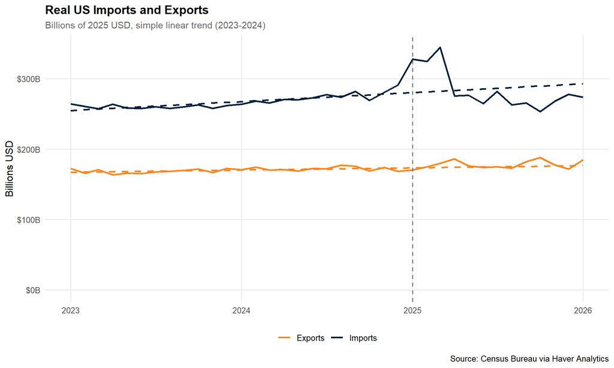

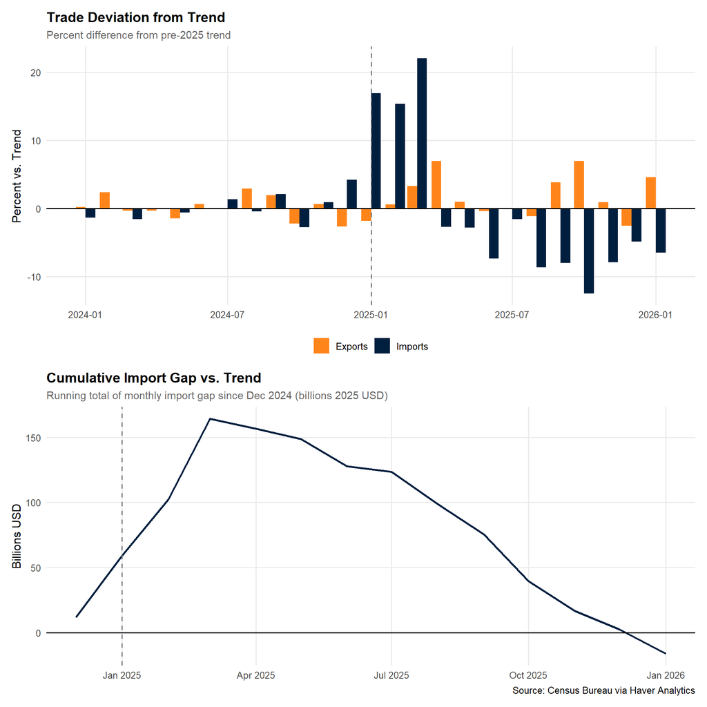

## Data Sources

All data in this report is pulled directly from Haver Analytics databases:

- **USECON**: U.S. Economic data
- **USNA**: National Accounts (PCE price indices)
- **USTRADE**: Trade data by country
- **USINT**: International trade
- **LABOR**: Employment by industry

## Appendix

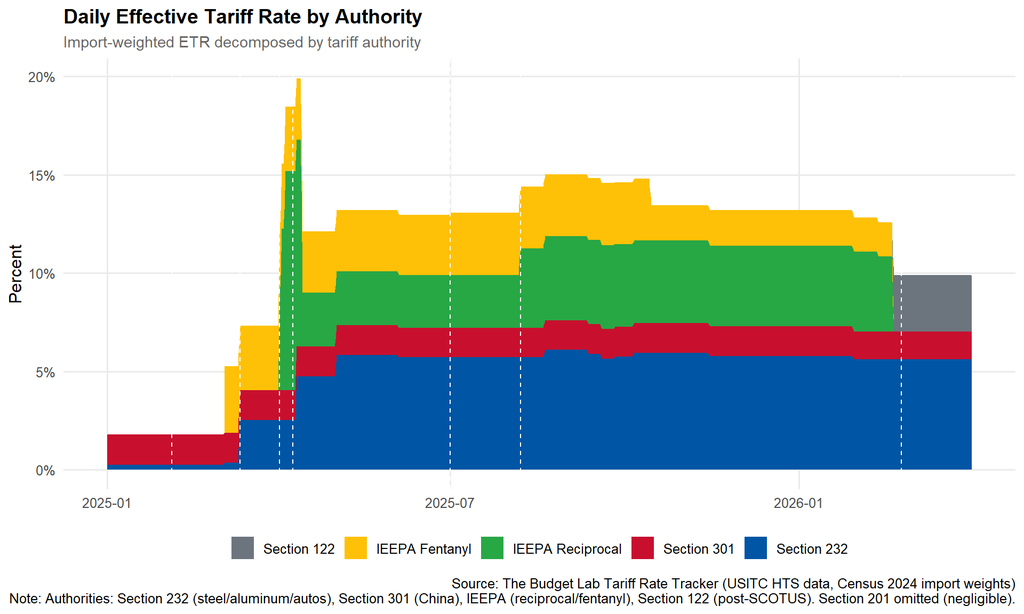

Table A1. Implied Consumer Passthrough – All PCE Goods (June 2025). Economy-wide effective tariff rate: 10.0%.

| Category | Inputs Import Share | Inputs Tariff Increase | Inputs Expected Effect | Price Changes 2025 Change | Price Changes vs LP Trend | Price Changes vs Log-Linear | Implied Passthrough 2025 Change | Implied Passthrough vs LP Trend | Implied Passthrough vs Log-Linear |
| --- | --- | --- | --- | --- | --- | --- | --- | --- | --- |
| Core Goods | 32.1% | 7.4 pp | 2.4% | 1.5% | 2.0% | 1.7% | 63% | 84% | 73% |
| Durables | 28.0% | 7.4 pp | 2.1% | 1.7% | 2.5% | 2.7% | 80% | 121% | 133% |

Table A2. Implied Consumer Passthrough – All PCE Goods (January 2026). Economy-wide effective tariff rate.

| Category | Inputs Import Share | Inputs Tariff Increase | Inputs Expected Effect | Price Changes 2025 Change | Price Changes vs LP Trend | Price Changes vs Log-Linear | Implied Passthrough 2025 Change | Implied Passthrough vs LP Trend | Implied Passthrough vs Log-Linear |
| --- | --- | --- | --- | --- | --- | --- | --- | --- | --- |
| Core Goods | 32.1% | 8.0 pp | 2.6% | 2.3% | 3.4% | 2.8% | 89% | 133% | 110% |
| Durables | 28.0% | 8.0 pp | 2.2% | 2.5% | 4.1% | 4.9% | 110% | 184% | 218% |

**Note:** Tables A1–A2 use overall PCE price indices (domestic + imported) rather than the import-weighted index used in the main text Tables 1a–1b.

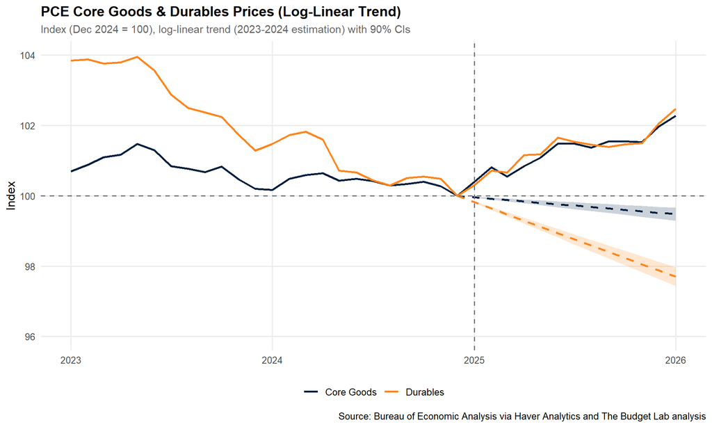

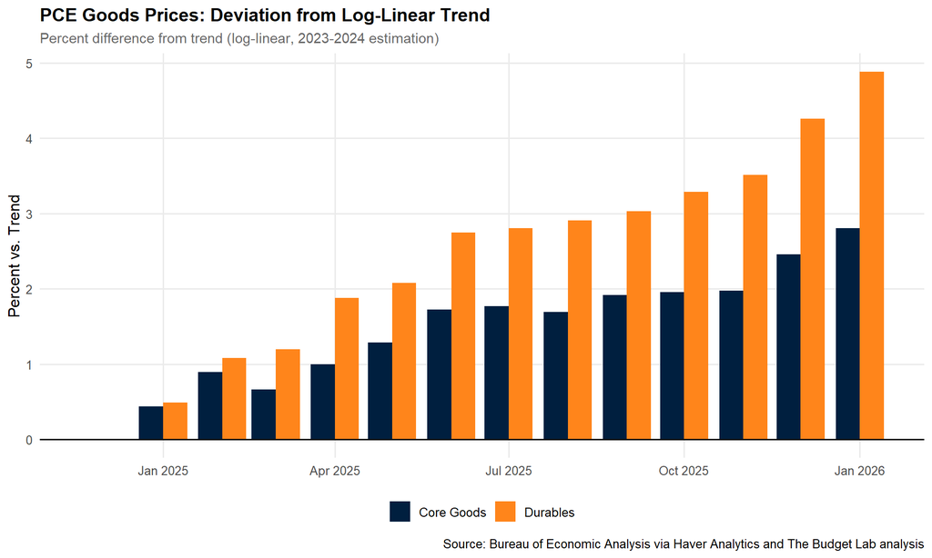

*Report generated on 2026-04-02 08:32:03.801573 using R R version 4.5.2 (2025-10-31 ucrt)*